# Problem Set 2

Author

Timi Evrenosoglu

Published

October 14, 2026

**GitHub repo:** https://github.com/Timievrenosoglu/EC422_PS2_Evrenosoglu.

## Data

```r
library(tidyquant)
library(tidyverse)
# unemp_raw <- tq_get(
#   c("UNRATE", "ORUR", "CAUR", "TXUR", "NYUR"),
#   get  = "economic.data",
#   from = "1976-01-01"
# )
#
# head(unemp_raw)
#
# dir.create("data", showWarnings = FALSE)
#
# write_rds(unemp_raw, "data/unemp_raw.rds")

unemp_raw = read_rds("data/unemp_raw.rds")
```

## Wrangle

```r
unemp <- unemp_raw |>
  rename(unemployment_rate = price) |>
  mutate(
    region = case_when(
      symbol == "UNRATE" ~ "United States",
      symbol == "ORUR"    ~ "Oregon",
      symbol == "CAUR"    ~ "California",
      symbol == "TXUR"    ~ "Texas",
      symbol == "NYUR"    ~ "New York",
    )
  )
# 4.2
unemp <- unemp |>
  arrange(region, date) |>
  group_by(region) |>
  mutate(
    unemployment_rate = replace(
      unemployment_rate,
      date == as.Date("2025-10-01"),
      unemployment_rate[date == as.Date("2025-09-01")]
    )
  ) |>
  ungroup()

unemp <- unemp |>
  arrange(region, date) |>
  group_by(region) |>
  mutate(unemployment_rate_change = unemployment_rate - lag(unemployment_rate)) |>
  ungroup()

unemp_summary <- unemp |>
  group_by(region) |>
  summarize(
    mean_rate = mean(unemployment_rate, na.rm = TRUE),
    min_rate  = min(unemployment_rate,  na.rm = TRUE),
    max_rate  = max(unemployment_rate,  na.rm = TRUE)
  )

# 4.3
unemp_top_increases <- unemp |>
  group_by(region) |>
  slice_max(order_by = unemployment_rate_change, n = 5) |>
  ungroup()

unemp_top_decreases <- unemp |>
  group_by(region) |>
  slice_min(order_by = unemployment_rate_change, n = 5) |>
  ungroup()

# 4.4
unemp_top_increases_no_covid <- unemp |>
  group_by(region) |>
  filter(year(date) != 2020) |>
  slice_max(order_by = unemployment_rate_change, n = 5) |>
  ungroup()

unemp_top_decreases_no_covid <- unemp |>
  group_by(region) |>
  filter(year(date) != 2020) |>
  slice_min(order_by = unemployment_rate_change, n = 5) |>
  ungroup()
```

## Visualization

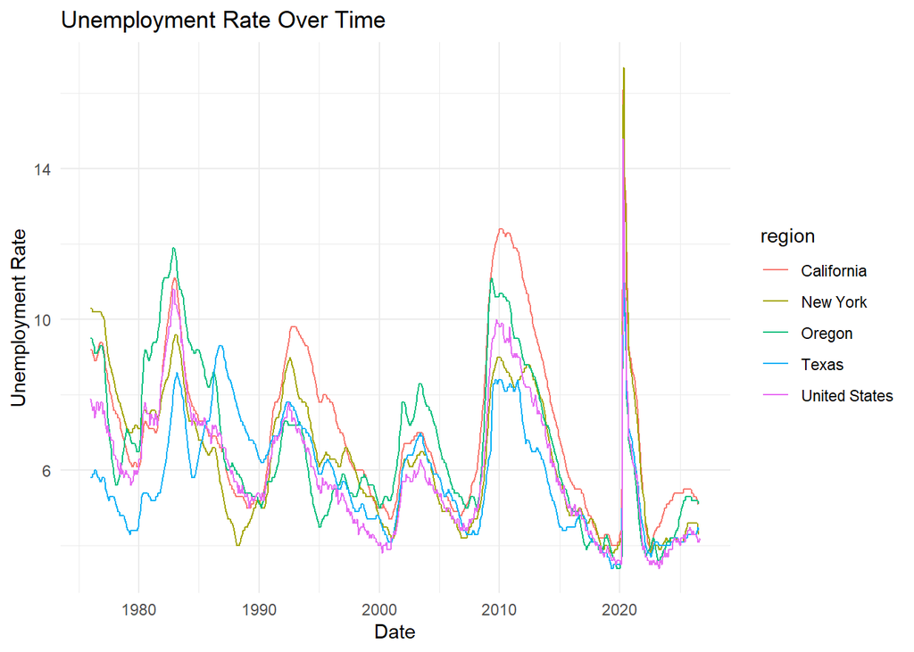

```r
# 5.1

ggplot(unemp, aes(x = date, y = unemployment_rate, color = region)) +
  geom_line() +
  labs(title = "Unemployment Rate Over Time", x = "Date", y = "Unemployment Rate") +
  theme_minimal()
```

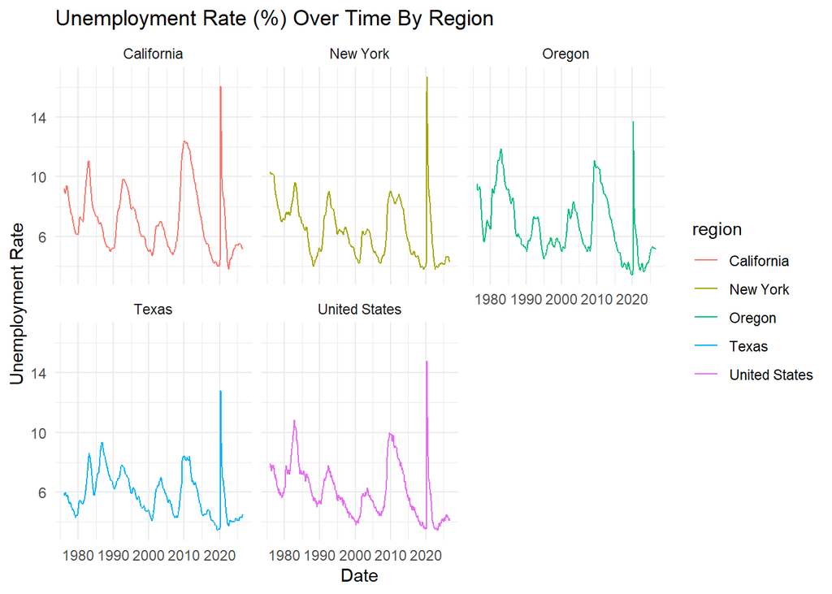

```r
# 5.2
ggplot(unemp, aes(x = date, y = unemployment_rate, color = region)) +
  geom_line() +   facet_wrap(~ region) +
labs(title = "Unemployment Rate (%) Over Time By Region", x = "Date", y = "Unemployment Rate") +
  theme_minimal()
```

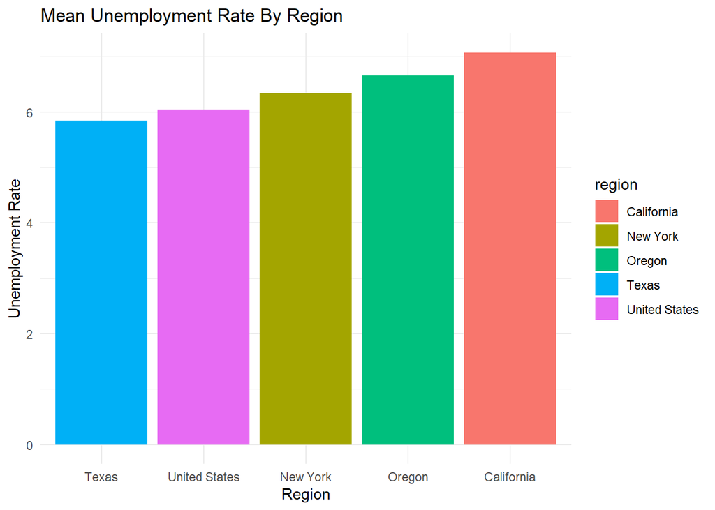

```r
ggplot(unemp_summary, aes(x = fct_reorder(region, mean_rate), y = mean_rate, fill = region)) +
  geom_col() +
  labs(title = "Mean Unemployment Rate By Region", x = "Region", y = "Unemployment Rate") +
  theme_minimal()
```

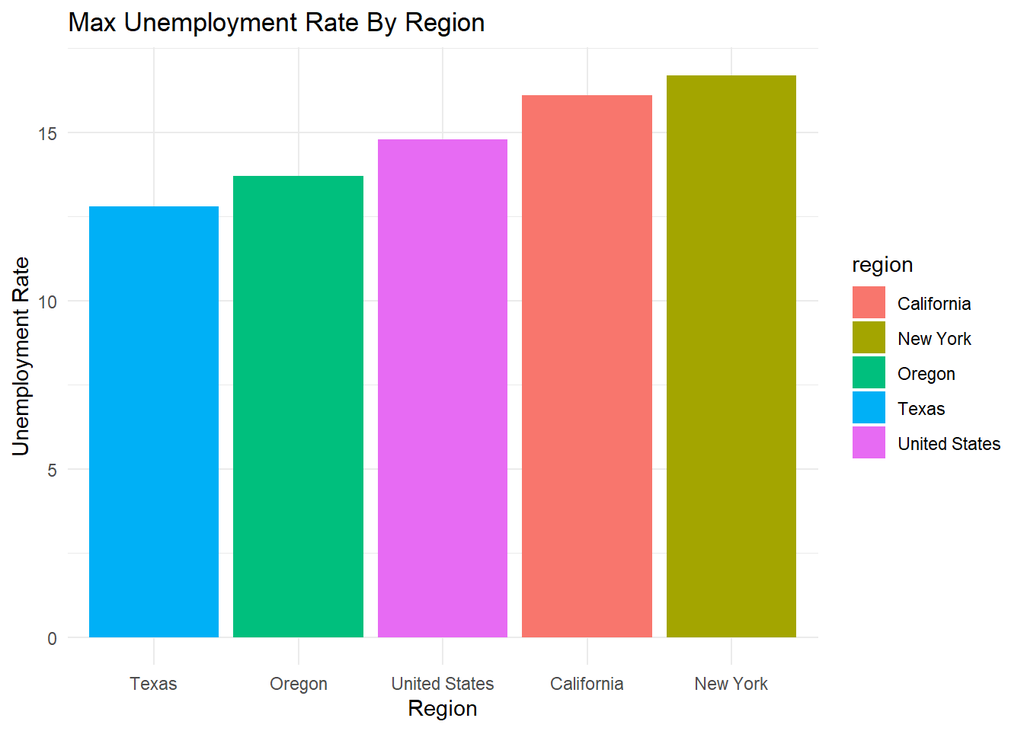

```r
# 5.3 - Personal Graph Choice
ggplot(unemp_summary, aes(x = fct_reorder(region, max_rate), y = max_rate, fill = region)) +
  geom_col() +
  labs(title = "Max Unemployment Rate By Region", x = "Region", y = "Unemployment Rate") +
  theme_minimal()
```

It is interesting to see that the order of regions differs between the mean and max values. For example, California has the highest mean, but only the second highest max. Also Oregon has the second highest mean, but the 4th largest max.

## Reflection

Overall it was a good refresher of using R and was relatively straightforward. Because I haven’t used R since EC 421 last fall, it was a good to work through some fill in the blank questions. I had to look up some of the arguments that were needed in the functions required by the question. Otherwise, most of the questions required some trial and error, and eventually I got to the desired output. I had never used Github before, but the instructions were clear and I am much more comfortable with using it now moving forward. I also feel like I am getting back up to speed with using R now, definetly not where I was last fall, but getting more and more comfortable with it.